# Linear Regression

# Nesting data AND fitting models

We’ll now turn our attention to fitting models to datasets nested within variables – meaning, essentially, that we’ll use nest() to create a list column containing datasets and fit separate models to each. This is very different from fitting nested models, even though the terminology is similar.

In the airbnb data, we might think that star ratings and room type affects price differently in each borough. One way to allow this kind of effect modification is through interaction terms:

- Is there an association with stars and price and does it differ by borough?

```r
nyc_airbnb |>
  lm(price ~ stars * borough + room_type * borough, data = _) |> #interaction terms
  broom::tidy() |>
  knitr::kable(digits = 3)
```

| term | estimate | std.error | statistic | p.value |
| --- | --- | --- | --- | --- |
| (Intercept) | 95.694 | 19.184 | 4.988 | 0.000 |
| stars | 27.110 | 3.965 | 6.838 | 0.000 |
| boroughBrooklyn | -26.066 | 25.080 | -1.039 | 0.299 |
| boroughQueens | -4.118 | 40.674 | -0.101 | 0.919 |
| boroughBronx | -5.627 | 77.808 | -0.072 | 0.942 |
| room_typePrivate room | -124.188 | 2.996 | -41.457 | 0.000 |
| room_typeShared room | -153.635 | 8.692 | -17.676 | 0.000 |
| stars:boroughBrooklyn | -6.139 | 5.237 | -1.172 | 0.241 |
| stars:boroughQueens | -17.455 | 8.539 | -2.044 | 0.041 |
| stars:boroughBronx | -22.664 | 17.099 | -1.325 | 0.185 |
| boroughBrooklyn:room_typePrivate room | 31.965 | 4.328 | 7.386 | 0.000 |
| boroughQueens:room_typePrivate room | 54.933 | 7.459 | 7.365 | 0.000 |
| boroughBronx:room_typePrivate room | 71.273 | 18.002 | 3.959 | 0.000 |
| boroughBrooklyn:room_typeShared room | 47.797 | 13.895 | 3.440 | 0.001 |
| boroughQueens:room_typeShared room | 58.662 | 17.897 | 3.278 | 0.001 |
| boroughBronx:room_typeShared room | 83.089 | 42.451 | 1.957 | 0.050 |

This works, but the output takes time to think through – the expected change in price comparing an entire apartment to a private room in Queens, for example, involves the main effect of room type and the Queens / private room interaction.

Alternatively, we can nest within boroughs and fit borough-specific models associating price with rating and room type:

```r
# we want to nest everything except for boro
nest_lm_res =
  nyc_airbnb |>
  nest(data = -borough) |>  # we have a tibble for boro and an entire df. Given this in a list column we can ask if its possible to fit a model to each variable by using mutate and map.
  mutate(
    models = map(data, \(df) lm(price ~ stars + room_type, data = df)),
    results = map(models, broom::tidy)) |>
  select(-data, -models) |>
  unnest(results)

# other method

nyc_airbnb %>%
  nest(data = - borough) %>%
  mutate(
    models = map(.x = data, ~lm(price~stars, data = .x)), #fitting a model across. broom tidying is tidying across models and creates a list column
    results = map(models, broom::tidy)
  ) %>%
  select(-data, -models) %>%
  unnest(results) %>%
  filter(term == "stars") # exploratory
```

```
## # A tibble: 4 × 6
##   borough   term  estimate std.error statistic  p.value
##   <fct>     <chr>    <dbl>     <dbl>     <dbl>    <dbl>
## 1 Bronx     stars     4.91      4.10      1.20 2.31e- 1
## 2 Queens    stars    15.8       5.63      2.81 5.06e- 3
## 3 Brooklyn  stars    28.0       3.10      9.02 2.13e-19
## 4 Manhattan stars    43.3       4.78      9.07 1.39e-19
```

```r
# another way of tidying
nyc_airbnb %>%
  nest(data = - borough) %>%
  mutate(
    models = map(.x = data, ~lm(price~stars, data = .x)), #fitting a model across. broom tidying is tidying across models and creates a list column
    results = map(models, broom::tidy)
  ) %>%
  select(-data, -models) %>%
  unnest(results) %>%
  filter(term != "(Intercept") %>%
  select(borough, term, estimate) %>%
  pivot_wider(
    names_from = borough,
    values_from = estimate
  )
```

```
## # A tibble: 2 × 5
##   term        Bronx Queens Brooklyn Manhattan
##   <chr>       <dbl>  <dbl>    <dbl>     <dbl>
## 1 (Intercept) 49.9    18.1    -11.3     -34.3
## 2 stars        4.91   15.8     28.0      43.3
```

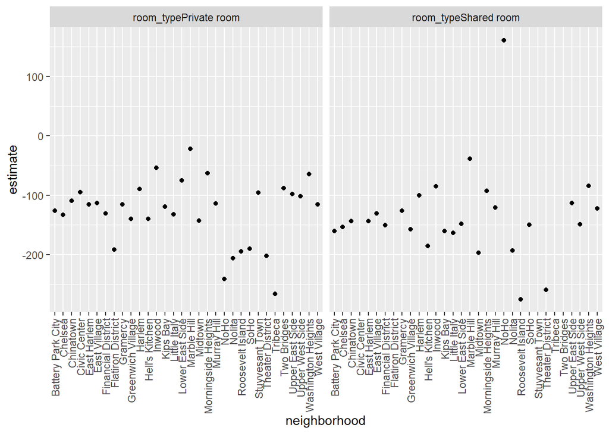

```r
# nesiting data and lookin at results is helful but lest nest even more if we want room type and stars in context of neighborhood within manhattan.

nyc_airbnb %>%
  filter(borough == "Manhattan") %>%
  nest(data = - neighborhood) %>%
  mutate(
    models = map(.x = data, ~lm(price~ stars + room_type, data = .x)), #nesting using this df and others then tidy others
    results = map(models, broom::tidy)
  ) %>%
  select(-data, -models) %>%
  unnest(results) %>% #unnest bc we dont need the df. So we are left with the impact of stars.
  filter(str_detect(term, "room_type")) %>%
  ggplot(aes(x= neighborhood, y = estimate))+
  geom_point()+
  facet_wrap(. ~ term)+
  theme(axis.text.x = element_text(angle = 90, vjust = 0.5, hjust = 1)) #adjudting the angle
```

```r
# from the graph we can see if we are comparing an entire home comapred to a shared room we'll see the areas where you  might save more money.
```

Fitting models to nested datasets is a way of performing stratified analyses. These have a tradeoff: stratified models make it easy to interpret covariate effects in each stratum, but don’t provide a mechanism for assessing the significance of differences across strata.

An even more extreme example is the assessment of neighborhood effects in Manhattan. The code chunk below fits neighborhood-specific models:

```r
manhattan_airbnb =
  nyc_airbnb |>
  filter(borough == "Manhattan")

manhattan_nest_lm_res =
  manhattan_airbnb |>
  nest(data = -neighborhood) |>
  mutate(
    models = map(data, \(df) lm(price ~ stars + room_type, data = df)),
    results = map(models, broom::tidy)) |>
  select(-data, -models) |>
  unnest(results)
```

And the chunk below shows neighborhood-specific estimates for the coefficients related to room type.

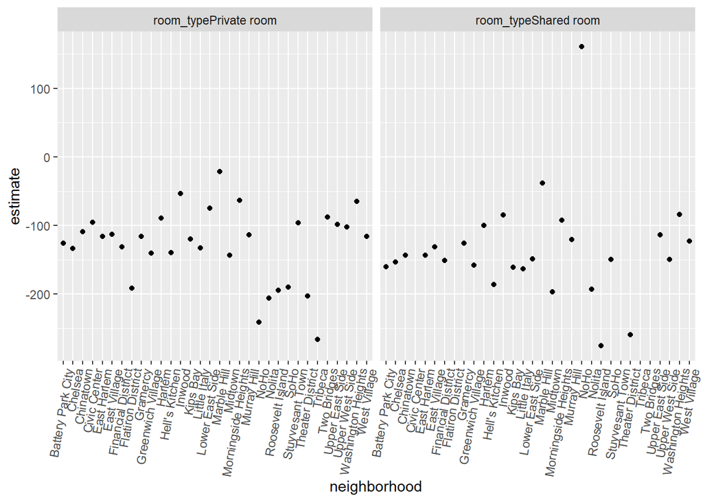

```r
manhattan_nest_lm_res |>
  filter(str_detect(term, "room_type")) |>
  ggplot(aes(x = neighborhood, y = estimate)) +
  geom_point() +
  facet_wrap(~term) +
  theme(axis.text.x = element_text(angle = 80, hjust = 1))
```

There is, generally speaking, a reduction in room price for a private room or a shared room compared to an entire apartment, but this varies quite a bit across neighborhoods.

With this many factor levels, it really isn’t a good idea to fit models with main effects or interactions for each. Instead, you’d be best-off using a mixed model, with random intercepts and slopes for each neighborhood. Although it’s well beyond the scope of this class, code to fit a mixed model with neighborhood-level random intercepts and random slopes for room type is below. And, of course, we can tidy the results using a mixed-model spinoff of the broom package.

```r
manhattan_airbnb |>
  lme4::lmer(price ~ stars + room_type + (1 + room_type | neighborhood), data = _) |>
  broom.mixed::tidy()
```

[output not shown]

Mixed models are pretty great!

# Binary outcomes

Linear models are appropriate for outcomes that follow a continuous distribution, but binary outcomes are common. In these cases, logistic regression is a useful analytic framework.

The Washington Post has gathered data on homicides in 50 large U.S. cities and made the data available through a GitHub repository; the final CSV is here. You can read their accompanying article here. We’ll use data on unresolved murders in Baltimore, MD to illustrate logistic regression in R. The code below imports, cleans, and generally wrangles the data for analysis.

```r
baltimore_df =
  read_csv("data/homicide-data.csv") |>
  filter(city == "Baltimore") |>
  mutate(
    resolved = as.numeric(disposition == "Closed by arrest"),
    victim_age = as.numeric(victim_age),
    victim_race = fct_relevel(victim_race, "White")) |>
  select(resolved, victim_age, victim_race, victim_sex)
```

Using these data, we can fit a logistic regression for the binary “resolved” outcome and victim demographics as predictors. This uses the glm function with the family specified to account for the non-Gaussian outcome distribution.

```r
fit_logistic =
  baltimore_df |>
  glm(resolved ~ victim_age + victim_race + victim_sex, data = _, family = binomial())
```

```r
fit_logistic |>
  broom::tidy() |>
  mutate(OR = exp(estimate)) |>
  select(term, log_OR = estimate, OR, p.value) |>
  knitr::kable(digits = 3)
```

[output not shown]

We can also compute fitted values; similarly to the estimates in the model summary, these are expressed as log odds and can be transformed to produce probabilities for each subject.

```r
baltimore_df |>
  modelr::add_predictions(fit_logistic) |>
  mutate(fitted_prob = boot::inv.logit(pred))
```